# Evaluating a Workplace Intervention with Viva Insights in R

2026-07-01

```r
knitr::opts_chunk$set(warning = FALSE, message = FALSE)
library(tidyverse)
library(vivainsights)
```

# Evaluating a Workplace Intervention

## Introduction

Organisations frequently run interventions aimed at improving how people work: a protected “focus day”, a meeting-reduction push, or a Microsoft 365 Copilot enablement wave for one team. The natural question is *did it actually work?* - and, just as importantly, *did anything simply move somewhere else?*

Answering this credibly needs more than a before-and-after comparison for the group that took part. A company-wide trend, a seasonal effect, or a change in how a metric is calculated can all masquerade as a programme effect. The antidote is a simple **quasi-experiment**:

- Compare a **treated** group (who received the intervention) against a **control** group (who did not).
- Split time into **Before**, **During**, and **After** windows.
- Use a **difference-in-differences** read: the treated group’s change minus the control group’s change.
- **Discount any signal that moves the same way in the control group**, because a change that shows up where there was no intervention cannot have been caused by it.

We demonstrate this on the built-in `pq_data` sample Person Query.

## Data preparation

`pq_data` is a weekly Person Query. We assign a treated group (here, one organisation that we imagine received the intervention) and a control group (everyone else), then split the weeks into three equal windows.

```r
data("pq_data", package = "vivainsights")

pq <- pq_data %>% mutate(MetricDate = as.Date(MetricDate))

# Treated vs control. In practice you would flag the population that actually
# received the intervention; here we use one organisation for illustration.
TREATED_ORG <- "IT"
pq <- pq %>%
  mutate(group = ifelse(Organization == TREATED_ORG, "Treated", "Control"))

# Before / During / After as three equal windows across the date range.
rng  <- range(pq$MetricDate)
cuts <- rng[1] + diff(rng) * c(1/3, 2/3)
pq <- pq %>%
  mutate(period = factor(
    case_when(
      MetricDate <  cuts[1] ~ "Before",
      MetricDate <  cuts[2] ~ "During",
      TRUE                  ~ "After"
    ),
    levels = c("Before", "During", "After")
  ))

count(pq, group, period)
```

```
## # A tibble: 6 × 3
##   group   period     n
##   <chr>   <fct>  <int>
## 1 Control Before  1856
## 2 Control During  1624
## 3 Control After   1856
## 4 Treated Before   544
## 5 Treated During   476
## 6 Treated After    544
```

The sample data contains no real intervention, so purely for demonstration we inject a modest, clearly labelled reduction in multitasking for the treated group during and after the programme. **Delete this block when using your own data**; it exists only so the method has a real effect to detect.

```r
pq <- pq %>%
  mutate(Multitasking_hours = case_when(
    group == "Treated" & period == "During" ~ Multitasking_hours * 0.92,
    group == "Treated" & period == "After"  ~ Multitasking_hours * 0.80,
    TRUE                                     ~ Multitasking_hours
  ))
```

## Two-stage aggregation

A robust group summary aggregates in **two stages**: first to a typical value per person (so a few very heavy or very light weeks do not dominate), then to a mean across people within each group and period. We wrap this in a small reusable function.

```r
two_stage_summary <- function(data, metric,
                              id = "PersonId", group = "group",
                              period = "period") {
  # Stage 1: person-level mean within each period
  s1 <- data %>%
    group_by(.data[[id]], .data[[group]], .data[[period]]) %>%
    summarise(person_mean = mean(.data[[metric]], na.rm = TRUE), .groups = "drop")

  # Stage 2: group mean across persons within each period
  s1 %>%
    group_by(.data[[group]], .data[[period]]) %>%
    summarise(value = mean(person_mean, na.rm = TRUE),
              n_persons = n(), .groups = "drop")
}

summ <- two_stage_summary(pq, metric = "Multitasking_hours")
summ
```

```
## # A tibble: 6 × 4
##   group   period value n_persons
##   <chr>   <fct>  <dbl>     <int>
## 1 Control Before  4.89       232
## 2 Control During  5.27       232
## 3 Control After   5.20       232
## 4 Treated Before  4.70        68
## 5 Treated During  4.47        68
## 6 Treated After   4.38        68
```

## Difference-in-differences

Now the key comparison. We look at each group’s change from Before to After, and take the difference between them. The control group’s change captures whatever was happening anyway; subtracting it isolates the treated-specific effect.

```r
wide <- summ %>%
  select(group, period, value) %>%
  pivot_wider(names_from = period, values_from = value) %>%
  mutate(change_before_after = After - Before)

wide
```

```
## # A tibble: 2 × 5
##   group   Before During After change_before_after
##   <chr>    <dbl>  <dbl> <dbl>               <dbl>
## 1 Control   4.89   5.27  5.20               0.314
## 2 Treated   4.70   4.47  4.38              -0.322
```

```r
did <- wide$change_before_after[wide$group == "Treated"] -
       wide$change_before_after[wide$group == "Control"]

did  # difference-in-differences (treated change minus control change)
```

```
## [1] -0.6359998
```

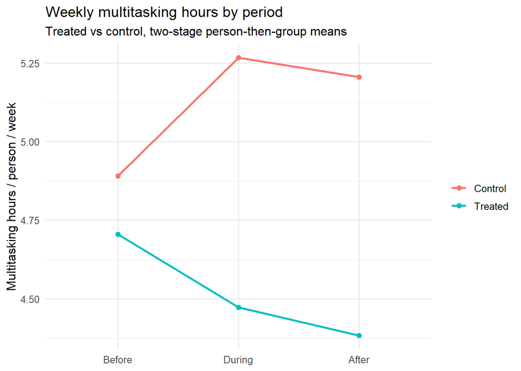

```r
ggplot(summ, aes(x = period, y = value, colour = group, group = group)) +
  geom_line(linewidth = 1) +
  geom_point(size = 2) +
  labs(
    title = "Weekly multitasking hours by period",
    subtitle = "Treated vs control, two-stage person-then-group means",
    x = NULL, y = "Multitasking hours / person / week", colour = NULL
  ) +
  theme_minimal(base_size = 12)
```

## Reading the result honestly

The **difference-in-differences** is the number to trust, not the treated group’s before/after change on its own. If the control group had moved by a similar amount, we would conclude the shift was an organisation-wide or seasonal effect (or even a change in how the metric is computed) and **discount it**, regardless of how good the treated group’s raw change looked. A change that appears equally in a group that received no intervention cannot have been caused by the intervention.

Two further checks are worth building in as a habit:

- **Look for displacement.** Re-run the same summary on adjacent behaviours (for a meeting-reduction programme: after-hours and weekend collaboration hours) to confirm the load did not simply move elsewhere. “It went down and did not come back somewhere else” is the claim a leader actually needs.
- **Prefer two-stage aggregation.** Person-then-group means stop a handful of extreme individuals or unequal week counts from skewing the comparison.

Transferable practices: always include a control population; structure the data as Before / During / After from the weekly person query; aggregate in two stages; and discount any signal that also moves in the control.

This design is reusable for any workplace intervention, including an AI-adoption programme. Framing a Copilot enablement wave as the “treated” group and measuring the difference-in-differences against a comparable control is a clean way to show whether adoption is associated with real shifts in collaboration or wellbeing signals, rather than relying on a simple before-and-after that a company-wide trend could easily confound.